# ARFA Scoring

Leandro Ledesma

2024-03-13

### Universal block code settings

```r
knitr::opts_chunk$set(echo = TRUE)
knitr::opts_chunk$set(message = FALSE)
knitr::opts_chunk$set(comment = NULL)
```

### Load in the data manipulation packages first

```r
library(tidyverse)
library(ggplot2)
library(ggpubr)
library(readxl)
library(kableExtra)
library(stringdist)
```

### Load in the data

We will be loading in the un-scored version of the ARFA- specifically the spelling portion of it.

```r
# Set the working directory
setwd("~/MegaGrant/ARFA Spelling Mistakes")

# load in the ARFA data that is unscored
ARFA.unscored <- read_excel("ARFA_Spelling_mistakes.xlsx")
```

### Explore our data

We have data from 661 unique IDs and there are 199 variables. From the 199 variables, 22 of them correspond to actual items. The first 12 items are words and the following 10 items are sentences. The original word document mentions that this was scored by how well they performed by item. With a score of 2 indicating no mistakes, a score of 1 indicating either 1 mistake or a repeat, and a score of 0 if there was more than one mistake. This, however, is not what was present in the actual un-scored excel file, since there are many types of errors that could be of interest.

```r
# Get the dimensions
dim(ARFA.unscored)
```

```
[1] 661 199
```

```r
# Obtain the number of unique ID's present
length(unique(ARFA.unscored$ID))
```

```
[1] 661
```

```r
# Graph the items with words
ARFA.unscored %>%
  select(ends_with("full")) %>%
  select(1:12) %>%
  head(10) %>%
  kbl() %>%
  kable_paper(bootstrap_options = "striped", full_width = F)
```

| Spelling_1_full | Spelling_2_full | Spelling_3_full | Spelling_4_full | Spelling_5_full | Spelling_6_full | Spelling_7_full | Spelling_8_full | Spelling_9_full | Spelling_10_full | Spelling_11_full | Spelling_12_full |
| --- | --- | --- | --- | --- | --- | --- | --- | --- | --- | --- | --- |
| помилование | поступиться | дисциплинированный | гуашь | довольно-таки | оранжерея | сверхестественный | безыдейный | прочь | траектория | полагаться | лужица |
| помилование | поступиться | дисциплинированный | гуашь | довольно-таки | оранжерея | сверхъестественный | безыдейный | прочь | траектория | полагаться | лужица |
| помилование | поступиться | дисциплинированный | гуаш | довольно таки | аранжерея | сверхъестественный | безидейный | прочь | траектория | пологаться | лужица |
| помилование | поступится | десциплинированный | гуашь | довольно-таки | оранджерея | сверхъестественный | безыдейный | проч | траэктория | полагаться | лужица |
| помилование | поступиться | дисциплинированый | гуаш | давольнотаки | аранжерея | сверхестественный | безидейный | прочь | траектория | полагаться | лужица |
| помилование | поступиться | дисциплинированный | гуашь | NA | оранжерея | сверхъестественный | безыдейный | прочь | траектория | полагаться | лужица |
| помилование | поступиться | дисциплинированный | гуашь | довольно таки | оранжерея | сверхъествественный | безидейный | прочь | троектория | полагаться | лужица |
| помилование | поступиться | дисциплинированный | гуашь | довольно та-ки | аранжерея | сверхестественный | безидейный | прочь | трояктория | пологаться | лужица |
| помилование | поступиться | дисциплинированный | гуашь | довольнотаки | оранжерея | сверхестественный | безыдейный | прочь | траектория | полагаться | лужица |
| помилование | поступитца | десцеплинированный | гуаш | довольнотаки | оранжерея | сверхестественный | безыдейный | прочь | троектория | палогаться | лужица |

```r
# Graph the items with sentences
ARFA.unscored %>%
  select(ends_with("full")) %>%
  select(13:22) %>%
  head(10) %>%
  kbl() %>%
  kable_paper(bootstrap_options = "striped", full_width = F)
```

| Spelling_13_full | Spelling_14_full | Spelling_15_full | Spelling_16_full | Spelling_17_full | Spelling_18_full | Spelling_19_full | Spelling_20_full | Spelling_21_full | Spelling_22_full |
| --- | --- | --- | --- | --- | --- | --- | --- | --- | --- |
| Цветок не мог расти долго не политым | На этом девишнике все девушки были незамужем | Птицелов прождал в лесу полночи | Не все жители Цюриха говорят по-французски | Они ненавидят загорать на солнце | Ей было незачто благодарить его | Поезд прибыл на северо-восточный вокзал | В девяносто пять лет ее сердце до сих пор хорошо работало | Во сколько он выехал навстречу гостям | Воин искуссно владеет мечом |
| Цветок не мог расти долго неполитым | На этом девичнике все девушки были не замужем | Птицелов прождал в лесу полночи | Не все жители Цюриха говорят по-французски | Они ненавидят загорать на солнце | Ей было не за что благодарить его | Поезд прибыл на северо-восточный вокзал | В девяносто пять лет ее сердце по-прежнему хорошо работало | Во сколько он выехал навстречу гостям | Воин искусно владеет мечом |
| Цветок не мог расти долго не политым | На этом девичнике все девушки были не замужем | Птицелов прождал в лесу пол-ночи | Не все жители Цюреха говорят по французски | Они ненавидят загорать на солнце | Ей было не за что благодарить его | Поезд прибыл на северо-восточный вокзал | В девяносто пять лет ее сердце попрежнему хорошо работало | Во сколько он выехал на встречу гостям | Воин искуссно владеет мечом |
| Цветок не мог рости долго не политым | На этом девичнике все девушки были не замужем | Птицелов прождал в лесу пол ночи | Не все жители Цурих говорят по французски | Они не навидят загорать на солнце | Ей было не за что благодарить его | Поезд прибыл на северо-восточный вокзал | В девяносто пять лет ее сердце по прежнему хорошо работало | Во сколько он выехал на встречу гостям | Воин искустно владеет мечом |
| Цветок не мог расти долго не политым | На этом девишнике все девушки были не замужем | Птицелов прождал в лесу полночи | Не все жители Цуриха говорят по французски | Они ненавидят загорать на солнце | Ей было не за что благодарить его | Поезд прибыл на северо-восточный вокзал | В девяносто пять лет ее сердце по прежнему хорошо работало | Во сколько он выехал на встречу к гостям | Воин искусно владеет мечом |
| Цветок не мог расти долго неполитым | На этом девичнике все девушки были не замужем | Птицелов прождал в лесу пол ночи | Не все жители говорят по французски | Они ненавидят загорать на солнце | Ей было не за что благодарить его | Поезд прибыл на северо-восточный вокзал | В девяносто пять лет ее сердце попрежнему хорошо работало | Восколько он выехал навстречу гостям | Воин искуссно владеет мечом |
| Цветок не мог расти долго не политым | На этом девичнике все девушки были не замужем | Птицелов прождал в лесу пол ночи | Ни все жители Цюиха говорят по-французски | Они ненавидят загорать на солнце | Ей было не за что благодарить его | Поезд прибыл на Северо-восточный вокзал | В девяносто пять лет её сердце по прежнему хорошо работало | Во сколько он выехал на встречу гостям | Воин искуссно владеет мечом |
| Цветок не мог расти долго неполитым | На этом девишнике все девушки были незамужем | Птицелов прождал в лесу пол ночи | Ни все жители Цуриха говорят по-французски | Они неновидят сгарать на солнце | Ей было не за что благодарить его | Поезд прибыл на Северо-Восточный вокзал | В девяносто пять лет ее сердце по-прежнему хорошо работало | Во сколько он выехал на встречу гостям | Воин искуссно владеет мечом |
| Цветок не мог расти долго неполитым | На этом девичнике все девушки были незаняты | Птицелов прождал в лесу пол ночи | Не все жители Цюриха говорят по-французски | Они ненавидят загорать на солнце | Ей было не за что благодарить его | Поезд прибыл на Северо-восточный вокзал | В девяносто пять лет ее сердце по-прежнему хорошо работало | Во сколько он выехал навстречу гостям | Воин искусно владеет мечом |
| Цветок не мог рости долго не политым | На этом дивишнике все девушки были не замужем | Птицелов прождал в лесу пол ночи | Не все жители Цуриха говорят по Французски | Они ненавидят сгорать на солнце | Ей было незачто благодарить его | Поезд прибыл на северо-восточный вокзал | В 95 лет ее сердце по прежнему хорошо работало | Во сколько он выехал на встречу гостям | Воин искусно владеет мечем |

### ARFA Scoring Technique 1a (original method)

Based on the instructions in the original method, we will create scripts that will score each of the 22 items for each person. If a subject is missing information for the repeat variable then they will be excluded from the analysis.

Essentially, we are giving each item a score of 0, 1, or 2.

```r
# Remove rows that have NA's for any of the Spelling_X_Rep Variables
missing.Rep.IDs <- ARFA.unscored %>%
  select(ID, ends_with("Rep")) %>%
  filter(!complete.cases(.)) %>%
  select(ID) %>%
  unlist()

# Remove theses subjects
length(missing.Rep.IDs)
```

```
[1] 53
```

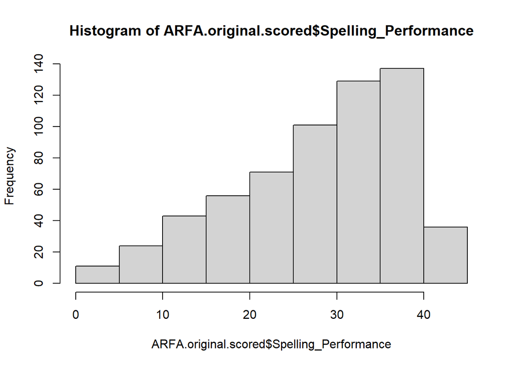

```r
# Save this new dataset
ARFA.unscored.no.missing.rep <- ARFA.unscored %>%
  filter(!(ID %in% missing.Rep.IDs))

# Create a list to save all of the scores
ARFA.scores.original.list <- list()

# Create vectors to extract the information we need
items <- paste("SP",1:22,".", sep="")
repeated <- paste("Spelling_",1:22,"_Rep",sep="")

for(ii in 1:22) {

  # Extract the all of the scoring variables for an item and the information on whether it was repeated or not
  current.item <- ARFA.unscored.no.missing.rep %>%
    select(starts_with(items[ii]), starts_with(repeated[ii]))

  # Rename the Spelling_X_variable so we can use the case_when() function on everyone, it should be second the last variable
  names.length <- length(names(current.item))
  names(current.item)[names.length] <- "Spelling_Rep"

  # Add the rows for each numeric value together, which indicates the number of spelling errors
  current.item$Row.Sum <- current.item %>%
    select_if(is.numeric) %>%
    rowSums(na.rm = TRUE)


  # Use the information from repetition and the sums of rows to develop a score of 0, 1, or 2
  current.item <- current.item %>%
    mutate(Score = case_when(

      Spelling_Rep == 'no' & Row.Sum == 0 ~ 2,
      Spelling_Rep == 'no' & Row.Sum == 1 ~ 1,
      Spelling_Rep == 'yes' & Row.Sum == 0 ~ 1,
      TRUE ~ 0

    ))

  # Save the score but rename it first
  ARFA.scores.original.list[[ii]] <- current.item$Score

}

# Take the scores in the list and cbind them and add the original ID's
ARFA.original.scored <- ARFA.scores.original.list %>%
  do.call(cbind,.) %>%
  data.frame() %>%
  cbind(ID = ARFA.unscored.no.missing.rep$ID)

# Turn the ID into a character variable
ARFA.original.scored$ID <- as.character(ARFA.original.scored$ID)

# Lastly, to get an overall measure of how well they performed in the spelling task, take another row sum of the scores to get on composite performance score.
ARFA.original.scored$Spelling_Performance <-  ARFA.original.scored %>%
    select_if(is.numeric) %>%
    rowSums(na.rm = TRUE)

# Let's view the distribution of scores for our independent variable
hist(ARFA.original.scored$Spelling_Performance)
```

```r
# Keep only the IDs and the composite scored variables
ARFA.original.final <-  ARFA.original.scored %>%
  select(ID, Spelling_Performance)
```

### ARFA Scoring Technique 1b (original method tweaked)

We are tweaking the original way fo scoring this task by removing the repetition portion as a consideration for scoring. Thus, each item will be score a 0, 1 or 2, but items that were spelled correctly will get a number 2 no matter what. By removing the need to have data on repetition, our sample size goes up.

Essentially, we are giving each item a score of 0, 1, or 2.

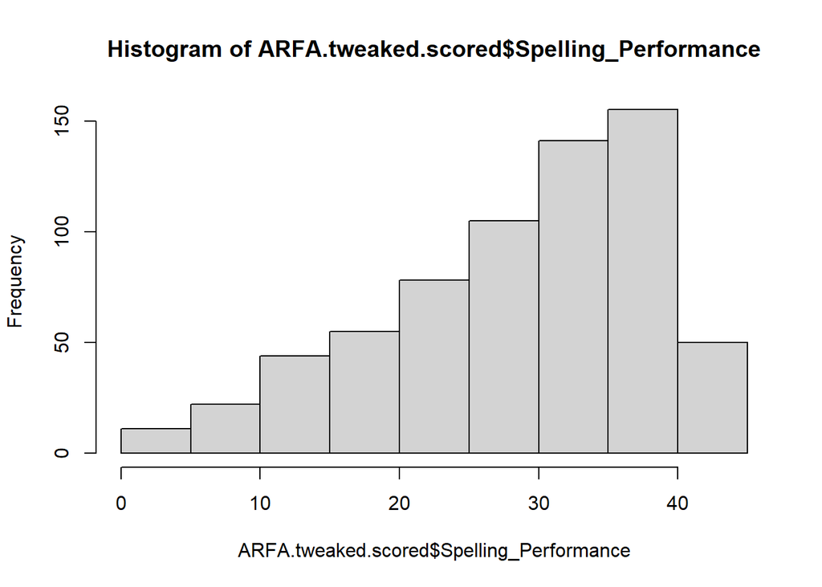

```r
# Create a list to save all of the scores
ARFA.scores.tweaked.list <- list()

# Create vectors to extract the information we need
items <- paste("SP",1:22,".", sep="")

for(ii in 1:22) {


  # Extract the all of the scoring variables for an item and the information on whether it was repeated or not
    current.item <- ARFA.unscored %>%
    select(starts_with(items[ii]))

  # Add the rows for each numeric value together, which indicates the number of spelling errors
  current.item$Row.Sum <- current.item %>%
    select_if(is.numeric) %>%
    rowSums(na.rm = TRUE)


  # Take the row sum and transform those values into either a 0, 1, or 2.
  # Below is saying, if there are more than 1 error, score it a 0
  # If there is 1 error, give it a point of 1,
  # And fi there are no errors, give it a point of 2.
  current.item.errors.scored <- ifelse(current.item$Row.Sum > 1, 0,
                                       ifelse(current.item$Row.Sum == 1, 1, 2))

  # Save the score but rename it first
  ARFA.scores.tweaked.list[[ii]] <- current.item.errors.scored

}

# Take the scores in the list and cbind them and add the original ID's
ARFA.tweaked.scored <- ARFA.scores.tweaked.list %>%
  do.call(cbind,.) %>%
  data.frame() %>%
  cbind(ID = ARFA.unscored$ID)

# Turn the ID into a character variable
ARFA.tweaked.scored$ID <- as.character(ARFA.tweaked.scored$ID)

# Lastly, to get an overall measure of how well they performed in the spelling task, take another row sum of the scores to get on composite performance score.
ARFA.tweaked.scored$Spelling_Performance <-  ARFA.tweaked.scored %>%
    select_if(is.numeric) %>%
    rowSums(na.rm = TRUE)

# Let's view the distribution of scores for our independent variable
hist(ARFA.tweaked.scored$Spelling_Performance)
```

```r
# Keep only the IDs and the composite scored variables
ARFA.tweaked.final <-  ARFA.tweaked.scored %>%
  select(ID, Spelling_Performance)
```

### ARFA Scoring Technique 2 (Levenshtein distance)

The next approach to scoring these data is not by how well they did but how many mistakes were made, and overall their severity of the mistake. To do this, we can use the stringdist formula. However, this will not apply to subjects that did not attempt to answer- so they will be removed.

To do this, I manually checked the Excel file with these data and copied and pasted the correct responses into the vector called ‘correct.items’. Next we will use the function stringdist(), which will return an output that represents how many characters were different in the responses from the correct spelling. A correct score is equal to 0. To not have biased answers from people who did not respond for an item, we have removed them as well.

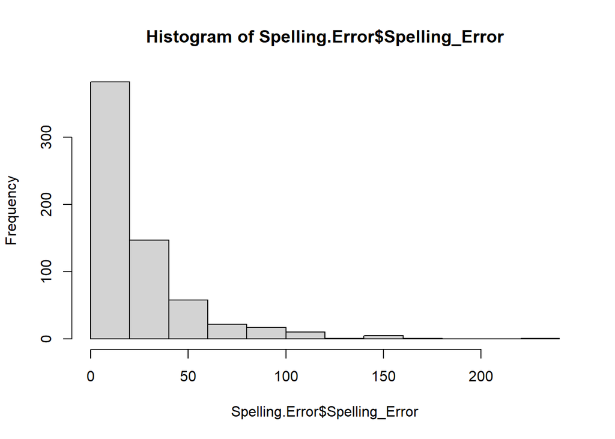

```r
# Keep subjects that have given a response to every single item
ARFA.unscored.no.missing.spelling <- ARFA.unscored %>%
  select(ID, ends_with("full")) %>%
  filter(complete.cases(.))

# Additionally, we want to remove any subjects that did not respond
ARFA.unscored.no.response.refusal <- ARFA.unscored.no.missing.spelling %>%
  filter_all(all_vars(!grepl("N/R", .)))


# Figure out the correct spelling for each item
correct.items <- c("помилование",
                   "поступиться",
                   "дисциплинированный",
                   "гуашь",
                   "довольно-таки",
                   "оранжерея",
                   "сверхъестественный",
                   "безыдейный",
                   "прочь",
                   "траектория",
                   "полагаться",
                   "лужица",
                   "Цветок не мог расти долго не политым",
                   "На этом девичнике все девушки были не замужем",
                   "Птицелов прождал в лесу полночи",
                   "Не все жители Цюриха говорят по-французски",
                   "Они ненавидят загорать на солнце",
                   "Ей было не за что благодарить его",
                   "Поезд прибыл на северо-восточный вокзал",
                   "В девяносто пять лет ее сердце по-прежнему хорошо работало",
                   "Во сколько он выехал навстречу гостям",
                   "Воин искусно владеет мечом")


# Create a performance variable for each item
ARFA.spellings <- ARFA.unscored.no.response.refusal %>%
  select_if(is.character)

# Create a list
Spelling.Error.list <- list()

for(ii in 1:22) {

Spelling.Error.list[[ii]] <- stringdist(unlist(ARFA.spellings[ii]), correct.items[ii])

}

# Combine performance into one data frame with ID
Spelling.Error <- Spelling.Error.list %>%
  do.call(cbind,.) %>%
  data.frame() %>%
  cbind(ID = ARFA.unscored.no.response.refusal$ID)

# Turn the ID into a character variable
Spelling.Error$ID <- as.character(Spelling.Error$ID)

# Lastly, to get an overall measure of how well they performed in the spelling task, take another row sum of the scores to get on composite performance score.
Spelling.Error$Spelling_Error <-  Spelling.Error %>%
    select_if(is.numeric) %>%
    rowSums(na.rm = TRUE)

# Let's view the distribution of scores for our independent variable
hist(Spelling.Error$Spelling_Error)
```

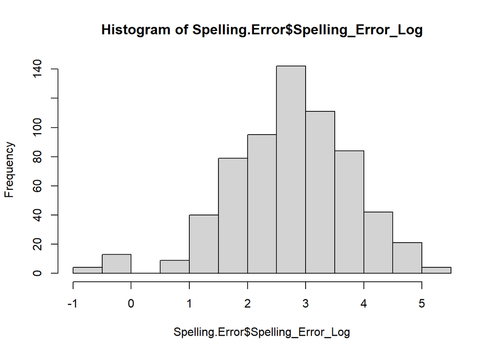

```r
# We also want to take the log transformation, however, top avoid errors- we need to take any subjects that got 0 errors and transform it into a small decimal number. This keeps the order of the original performance while preventing a value of infinity from the log transformation.
Spelling.Error <- Spelling.Error %>%
  mutate(Spelling_Error = ifelse(Spelling_Error == 0, .5, Spelling_Error))

# Decide to take the log of it cause why not
Spelling.Error$Spelling_Error_Log <- log(Spelling.Error$Spelling_Error)

# Let's view the data transformation
hist(Spelling.Error$Spelling_Error_Log)
```

```r
# Keep only the IDs and the composite scored variables
Spelling.Error.final <-  Spelling.Error %>%
  select(ID, Spelling_Error, Spelling_Error_Log)
```

### Visualizing the task

```r
Task <- tibble(`item num` = 1:22,
                item = correct.items,
               repeated = rep(c("Yes  No"),22),
               score = rep(c("2 1 0"),22))
# Visualize the task
Task  %>%
  kbl(title = "ARFA Spelling Assessment") %>%
  kable_paper(bootstrap_options = "striped", full_width = F)
```

| item num | item | repeated | score |
| --- | --- | --- | --- |
| 1 | помилование | Yes No | 2 1 0 |
| 2 | поступиться | Yes No | 2 1 0 |
| 3 | дисциплинированный | Yes No | 2 1 0 |
| 4 | гуашь | Yes No | 2 1 0 |
| 5 | довольно-таки | Yes No | 2 1 0 |
| 6 | оранжерея | Yes No | 2 1 0 |
| 7 | сверхъестественный | Yes No | 2 1 0 |
| 8 | безыдейный | Yes No | 2 1 0 |
| 9 | прочь | Yes No | 2 1 0 |
| 10 | траектория | Yes No | 2 1 0 |
| 11 | полагаться | Yes No | 2 1 0 |
| 12 | лужица | Yes No | 2 1 0 |
| 13 | Цветок не мог расти долго не политым | Yes No | 2 1 0 |
| 14 | На этом девичнике все девушки были не замужем | Yes No | 2 1 0 |
| 15 | Птицелов прождал в лесу полночи | Yes No | 2 1 0 |
| 16 | Не все жители Цюриха говорят по-французски | Yes No | 2 1 0 |
| 17 | Они ненавидят загорать на солнце | Yes No | 2 1 0 |
| 18 | Ей было не за что благодарить его | Yes No | 2 1 0 |
| 19 | Поезд прибыл на северо-восточный вокзал | Yes No | 2 1 0 |
| 20 | В девяносто пять лет ее сердце по-прежнему хорошо работало | Yes No | 2 1 0 |
| 21 | Во сколько он выехал навстречу гостям | Yes No | 2 1 0 |
| 22 | Воин искусно владеет мечом | Yes No | 2 1 0 |

### Save the data

Now we will save our predictor variables

```r
# Set the working directory to save our data
setwd("~/Masters Project/cleaned_predictor_covariates")

# Save the version of Spelling Performance
write_csv(ARFA.original.final, file = "ARFA.Spelling.Original.Scored.csv")

# Save the tweaked version of Spelling performance
write_csv(ARFA.tweaked.final, file = "ARFA.Spelling.Tweaked.Scored.csv")

# Save the version of
write_csv(Spelling.Error.final, file = "ARFA.Spelling.Levenshtein.Scored.csv")
```